# Part II - (Breast Cancer Data Exploration)

## by (Rutherford Kofi Brandful)

## Investigation Overview

> The overall goal was to look into the features of a benign,malignant and pre-malignant cancer cells. So by providing visualizations, it will be easier to see which category a cell belongs in terms of it's diagnosis.

## Dataset Overview

> Provide a brief overview of the dataset to be presented here. The dataset is a data of cancer cells being studied. It contains 604 rows with 32 variables after being cleaned. With one categorical variable and the rest being numerical variables, I looked into what these numerical variables tell a cell,as tp whether it is cancerous or not.

## (Visualization 1)

```
Malignant Patient Count(M): 212
Pre-Malignant Patient Count(P): 34
Benign Patient Count(B): 358
```

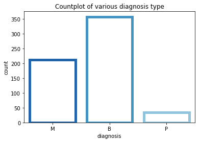

## (Visualization 2)

> Now, I look into the percentage of the diagnosis cells using a donut plot as it gives the numbers in a better perspective.

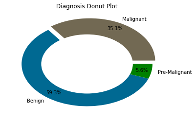

## (Visualization 3)

> Here, I use a pairplot to look into how the benign, pre-malignant and malignant cells behave in terms of radius,area,perimeter and compactness. As noted, pre-malignant cells have no definite trend. Focusing on the benign and malignant cells, you could see benign cells are always in the lower end of the graph, suggesting benign cells have lower values of radius,area and perimeter whiles malignant cells have larger values of these same criteria,suggesting they have higher measurement values.

```
Text(0.5,1.05,'Pairplot of the three main cell types')
```

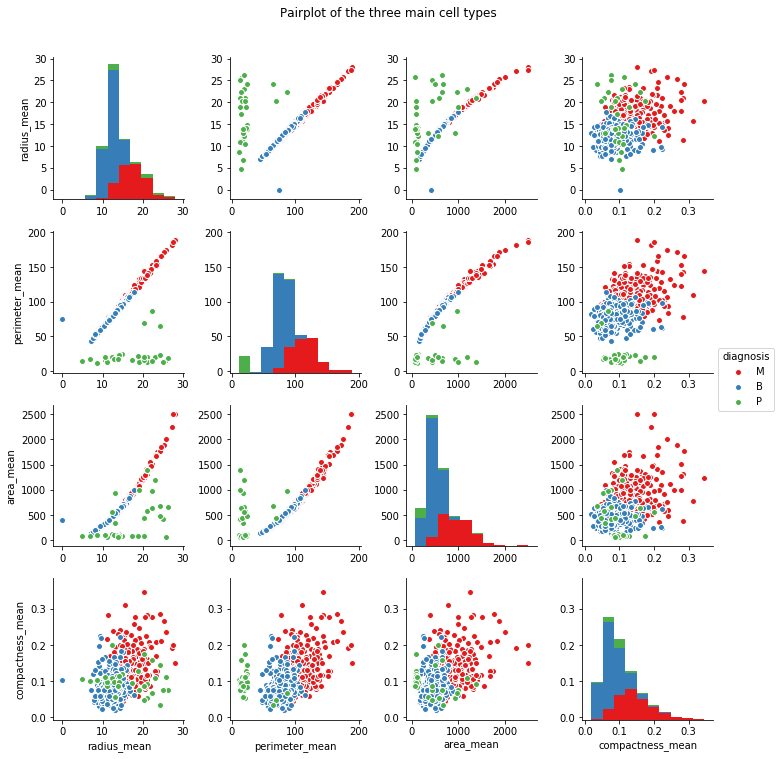

## (Visualization 4)

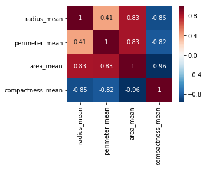